# Support Vector Machines

To demonstrate SVM, it is easiest to work in low dimensions, so we can visualize the data.

## Linear SVM Classifier

Let’s generate some data in two dimensions and make them a little separated.

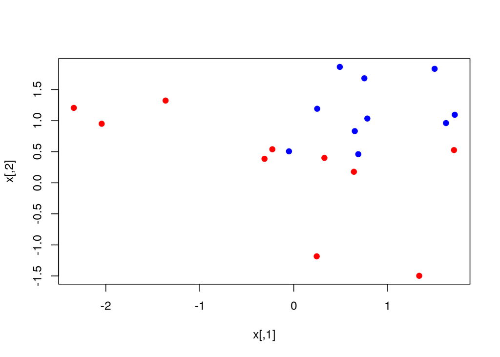

```r
set.seed(10111)
x=matrix(rnorm(40),20,2)
# create normally distributed x matrix of 20 observations
# in 2 classes over 2 variables
y=rep(c(1,-1),c(10,10))
# create y variables of -1 or +1 with 10 variables in
# each class
x[y==1,]=x[y==1,]+1
# move y variables means from 0 to 1 in each coordinate
plot(x,col=y+3,pch=19)
```

Now we will load the package `e1071` which contains the `svm` function for Support Vector Machine. We use this function to compute the SVM fit. Notice that we have to specify a `cost` parameter, which is the tuning parameter for the SVM.

```r
library(e1071)
dat=data.frame(x,y=as.factor(y))
# create dataframe of our normally distributed data
# with y as a factor variable
svmfit=svm(y~.,data=dat,kernel='linear',cost=10,scale=FALSE)
# dataframe will be unpacked as two-column with x1 and x2
# cost of 10 and scale tells SVM not to standardize variables
print(svmfit)
```

```
##
## Call:
## svm(formula = y ~ ., data = dat, kernel = "linear", cost = 10,
##     scale = FALSE)
##
##
## Parameters:
##    SVM-Type:  C-classification
##  SVM-Kernel:  linear
##        cost:  10
##       gamma:  0.5
##
## Number of Support Vectors:  8
```

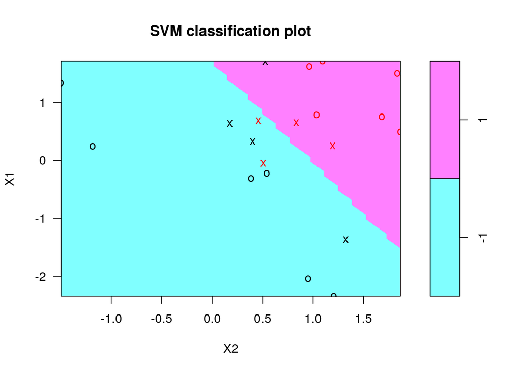

```r
# prints summary including the number of support vectors
# i.e., number of points used as support points
plot(svmfit,dat)
```

```r
# plots a rather ugly results of the SVM fit
```

As mentioned in the chapter, the plot function is crude, and breaks with convention to plot X2 on the horizontal axis and X1 on the vertical axis. R would by default plot in the opposite way. Now let’s make our own plot.

First, we make a grid of the values for X1 and X2. We will write a function to do this, in case we want to reuse it. It uses the function `expand.grid` and produces the coordinates of `n*n` points on a lattice covering the domain `x`. Having made the lattice, we make a prediction at each point on the lattice. We then plot the lattice, color-coded according to the classification, which allows us to see the decision boundary.

The support points (points on the margin or on the wrong side of the decision boundary) are indexed in the `$index` component of the fit.

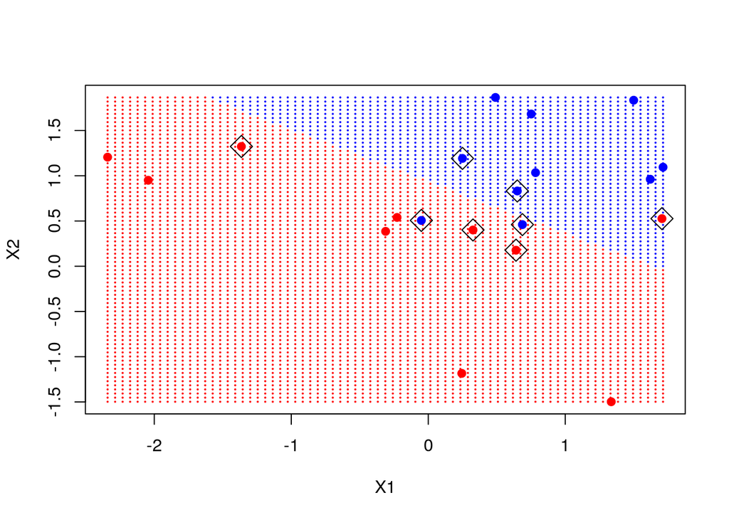

```r
make.grid=function(x,n=75){
  # takes argument x and makes default 75 points in each
  # direction to initialize the grid (n x n)
  grange=apply(x,2,range)
  # apply function find that range of variables in x
  x1=seq(from=grange[1,1],to=grange[2,1],length=n)
  x2=seq(from=grange[1,2],to=grange[2,2],length=n)
  # use seq function to go from x min to x max with length n
  expand.grid(X1=x1,X2=x2)
  # expand.grid takes sequences of numbers and makes lattice
}
xgrid=make.grid(x) # create grid using x data set
ygrid=predict(svmfit,xgrid) # make predictions based on svmfit
plot(xgrid,col=c('red','blue')[as.numeric(ygrid)],pch=20,cex=0.2)
# after plotting lattice we can see the decision boundary
# based on the predictions from the SVM fit
points(x,col=y+3,pch=19)
# plot original points to visualize quality of
# the derived decision boundary
points(x[svmfit$index,],pch=5,cex=2)
```

```r
# plot support points used to derive decision boundary
```

The `svm` function is not too user-friendly in that we have to do a bit of extra work to get back the linear coefficients, as described in the chapter text. Probably the reason is that it only makes sense to return coefficients for linear kernels, and the function is more general. Here we will use a formula to extract the coefficients. For those interested in the origins of this formula, see Chapter 12 of the textbook *Elements of Statistical Learning*.

We extract the linear coefficients, and then using simple alegbra we include the decision boundary and two margins.

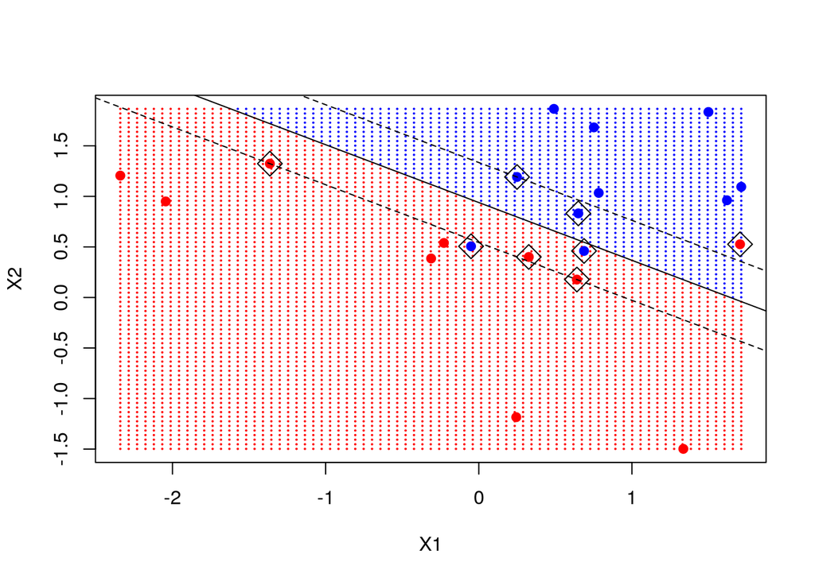

```r
beta=drop(t(svmfit$coefs)%*%x[svmfit$index,])
beta0=svmfit$rho
# above equations are from Ch. 12 of ESL textbook
# replot the lattice, data, and support points
plot(xgrid,col=c('red','blue')[as.numeric(ygrid)],pch=20,cex=0.2)
points(x,col=y+3,pch=19)
points(x[svmfit$index,],pch=5,cex=2)
# recall for linear function we have the form
# B0 + B1x1+ B2x2 + B3x2 +.... BpXp
# from this equation we need slop and intercept
# for the decision boundary which can be given to abline
abline(beta0/beta[2],-beta[1]/beta[2])
# can also include upper and lower margins
abline((beta0-1)/beta[2],-beta[1]/beta[2],lty=2)
abline((beta0+1)/beta[2],-beta[1]/beta[2],lty=2)
```

```r
# note some of support points are exactly on margin
# others are located inside margins
```

## Nonlinear Support Vector Machine

Now we will run the SVM on data where a non-linear boundary is called for. We will use a mixture of data from the *Elements on Statistical Learning* textbook.

```r
load(url("http://www-stat.stanford.edu/~tibs/ElemStatLearn/datasets/ESL.mixture.rda"))
# data set URL for data in 2 dimensions with non-linear boundary
names(ESL.mixture)
```

```
## [1] "x"        "y"        "xnew"     "prob"     "marginal" "px1"
## [7] "px2"      "means"
```

```r
# note that ESL.mixture has some variables that we
# have already defined; those should be reset
rm(x,y)
# remove x and y from previous examples
attach(ESL.mixture)
```

These data are already two-dimensional. Let’s plot them and fit a non-linear SVM using a radial kernel.

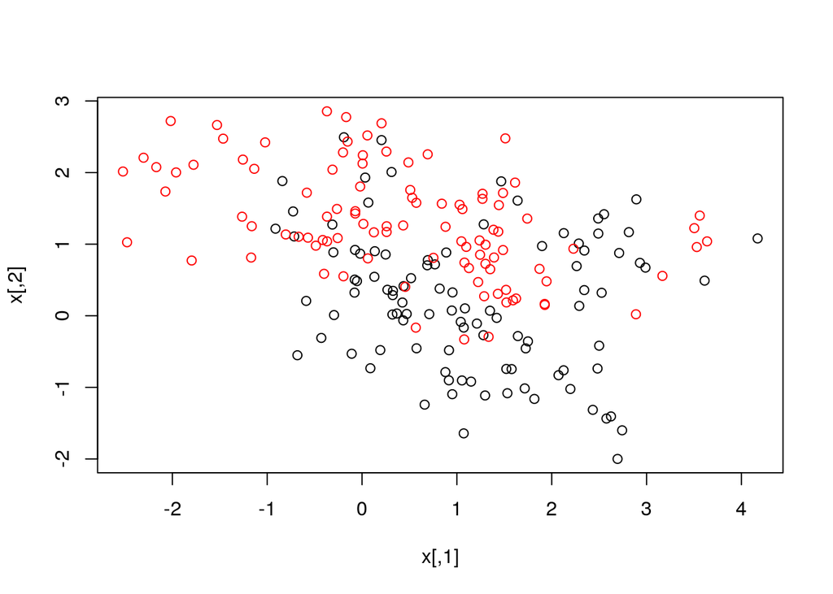

```r
plot(x,col=y+1)
```

```r
dat=data.frame(y=factor(y),x)
fit=svm(factor(y)~.,data=dat,scale=FALSE,kernel="radial",cost=5)
# radial kernel SVM with cost factor 5, unscaled
```

Now we are going to create a grid as before and make predictions on the grid. These `ESL.mixture` data have grid points `px1` and `px2` included in the data frame, so we can just use `expand.grid` directly.

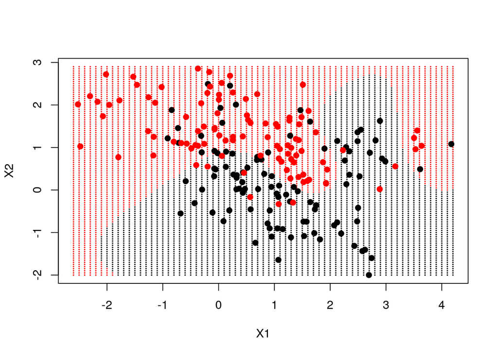

```r
xgrid=expand.grid(X1=px1,X2=px2)
ygrid=predict(fit,xgrid)
plot(xgrid,col=as.numeric(ygrid),pch=20,cex=0.2)
# plot the non-linear decision boundary derived
# from radial kernel SVM fit
points(x,col=y+1,pch=19)
```

```r
# check with original data points
```

We can take this a step further and have the `predict` function produce the actual function estimates at each of our grid points (i.e., return the decision boundary function). We can include the actual desicion boundary function in the plot by making use of the `contour` function.

Note: Because this is simulated data, on the dataframe is also the variable `prob`, which is the *true* probability of class 1 (versus class 0) for these data at each of the grid points. If we plot its 0.5 contour, that will give us the *Bayes Decision Boundary*, which is the best result one could ever theoretically achieve.

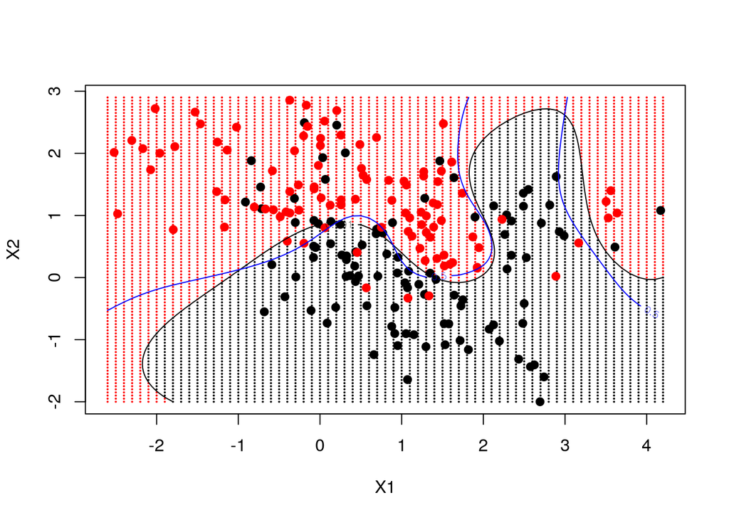

```r
func=predict(fit,xgrid,decision.values=TRUE)
# use decision.values TRUE to return the actual function
# and not just the classification
# returns it as an attribute of the function
func=attributes(func)$decision
# call attributes of the function and pull out $decision
# now recreate lattice plot and add data points
xgrid=expand.grid(X1=px1,X2=px2)
ygrid=predict(fit,xgrid)
plot(xgrid,col=as.numeric(ygrid),pch=20,cex=0.2)
points(x,col=y+1,pch=19)
# use contour function to plot decision boundary
contour(px1,px2,matrix(func,69,99),level=0.001,add=TRUE)
# contour needs grid points as input and a matrix
# of the function you want to contour
# here px1 and px2 have dimensions of 69 and 99
contour(px1,px2,matrix(prob,69,99),level=0.5,add=TRUE,col='blue')
```

```r
# include contour for Bayes Decision Boundary from
# true probabilities of simulated data
# non-linear SVM does a good job of reproducing it
```